# Homework 01

## Question 1 (Least squares and matrix calculations)

Set the random seed to 43201. Generate $n=100$ observations with $p=5$ predictors according to

$$x_{ij}\overset{\mathrm{iid}}{\sim}N(0,1),
\qquad
\varepsilon_i\overset{\mathrm{iid}}{\sim}N(0,0.7^2),$$

with all predictors and errors generated independently. Let

$$\mathbf X
=
\begin{bmatrix}
\mathbf 1 & \mathbf x_1 & \cdots & \mathbf x_5
\end{bmatrix},
\qquad
\boldsymbol\beta
=
(3,1.4,-0.9,0.7,0,1.1)^{\mathsf T},$$

and generate

$$\mathbf y=\mathbf X\boldsymbol\beta+\boldsymbol\varepsilon.$$

1. Generate the data and report the dimensions and rank of $\mathbf X$. Calculate the least-squares estimate $\widehat{\boldsymbol\beta}$ using a numerically stable least-squares routine, without explicitly calculating $(\mathbf X^{\mathsf T}\mathbf X)^{-1}$. Compare the estimates with the coefficients used to generate the data.

```r
set.seed(43201)

n <- 100
p <- 5

x <- matrix(rnorm(n * p), nrow = n, ncol = p)
X <- cbind(1, x)

beta <- c(3, 1.4, -0.9, 0.7, 0, 1.1)

epsilon <- rnorm(n, mean = 0, sd = 0.7)
y <- as.vector(X %*% beta + epsilon)

dim(X)
```

```
[1] 100   6
```

```r
qr(X)$rank
```

```
[1] 6
```

```r
beta_hat <- qr.solve(X, y)

cbind(
  True = beta,
  Estimated = beta_hat
)
```

```
     True  Estimated
[1,]  3.0  3.0063210
[2,]  1.4  1.4171604
[3,] -0.9 -0.8883453
[4,]  0.7  0.7952834
[5,]  0.0  0.0484378
[6,]  1.1  1.1319341
```

2. Calculate the fitted values, the residual vector $\mathbf r=\mathbf y-\mathbf X\widehat{\boldsymbol\beta}$, and the training root mean squared error

$$\operatorname{RMSE}
=
\left(
\frac{1}{n}\sum_{i=1}^{n}r_i^2
\right)^{1/2}.$$

```r
y_hat <- as.vector(X %*% beta_hat)
r <- y - y_hat

rmse <- sqrt(mean(r^2))

y_hat
```

```
  [1]  3.6537811  5.2625429 -3.9056470  4.0962621  1.2878270  0.4650240
  [7]  3.7429873  2.1336177  0.1026971  3.5941461  6.4540634  5.0870964
 [13]  4.1792817  3.1772805  4.4743146 -0.8853939  2.9032980  1.2351530
 [19]  3.5774346  2.2154812  1.5981803  7.2794914  1.4839547  8.2608034
 [25]  5.1318068  0.4993026  4.3010852 -2.7251533 -0.5692259  4.4375447
 [31]  2.5098211  4.3059701  0.4997676  8.3513720  4.0213612  0.8680860
 [37]  5.0012684 -0.9573978  2.6262466  3.8880220  4.9831630  2.9187817
 [43]  3.7311949  1.4500728  3.8009570  2.8415251  2.4431609  2.4993488
 [49]  0.2381805  2.4130118  2.5671474  1.2421449  0.1755827  1.8970830
 [55]  0.5901987  1.9437212  2.7720738  2.9190047  3.7684725  4.6344933
 [61]  2.6850810  1.2391265  1.3484371  8.8732472  5.4747753  5.5643145
 [67]  4.4717060  1.2139180  3.2173956  4.9187249  2.8212360  3.3148474
 [73]  1.6998144  2.7475973  3.1016138  5.8157161  6.1314567  2.7578962
 [79]  1.9614602  1.9158529  2.5407568  1.9878374  2.4148005  3.5453782
 [85]  2.2585238  1.4980764  5.7966778  1.9665059  3.1226667  4.2983045
 [91]  4.8301574  6.1702324  4.2082948  2.0429316  0.3431711  3.4705676
 [97]  0.8936651  3.6903140  0.8875368  2.2400590
```

```r
r
```

```
  [1] -1.068183362 -0.414345608 -0.215437036 -0.473141500  0.986867645
  [6] -0.301444813 -0.373781318  1.389820492 -0.553939879  0.646955729
 [11] -0.351789519  0.159876003 -0.777972124 -0.882571675 -1.419195631
 [16] -0.138712197 -0.576121118 -1.496656115  0.902599186 -0.959994579
 [21]  0.560638135 -0.154392518  0.077872367 -1.110577018  0.418314896
 [26] -0.800854665  0.699059370 -0.760193268  0.604042279  0.428810449
 [31] -0.321362202  0.558435064  1.814788693 -0.793878319  0.310071701
 [36]  0.201248098 -0.172046005  0.196440086  1.520680868 -0.093821877
 [41]  0.362255882 -0.540743432 -0.055150876  0.977329301  0.572627181
 [46] -0.027602793 -0.367896959  0.403507465 -0.211829167  0.155037715
 [51]  1.187082129 -0.485040243  0.198319585 -0.405747721 -0.146493678
 [56] -0.069633295  0.110411308 -0.468853646  1.056922266  0.247941429
 [61] -0.652660910 -0.771239805 -0.007033495  0.603117874 -0.209382743
 [66] -0.593536754  0.367517104  0.642263275  0.115872120  0.474883045
 [71] -0.720335973 -0.492239022 -0.017790628  1.226860187  0.029727817
 [76] -0.104984662  0.287886500 -0.935295270  0.195043751 -0.068067011
 [81]  0.422144724  0.541484980  0.725991278  0.431591788 -0.923349124
 [86] -0.073752688  0.630673921 -0.884816200 -0.273777687 -1.503182793
 [91]  0.485492901  1.072272156 -0.480552667 -0.984509730 -0.254845630
 [96]  0.089226105  0.655071277  0.718830324 -0.492629079  0.969479585
```

```r
rmse
```

```
[1] 0.6763696
```

3. Report $\lVert\mathbf X^{\mathsf T}\mathbf r\rVert_\infty$. Explain why this value should be close to zero and what it tells us about the residual vector.

```r
Xt_r <- t(X) %*% r
infinity_norm <- max(abs(Xt_r))

infinity_norm
```

```
[1] 3.019807e-14
```

The value of the infinity norm is very close to zero:

$$\left\|X^{\mathsf T}r\right\|_{\infty} \approx 0.$$

This occurs because the least-squares estimate satisfies the normal equations

$$X^{\mathsf T}X\widehat{\beta}
=
X^{\mathsf T}y.$$

Since the residual vector is

$$r
=
y-X\widehat{\beta},$$

we have

$$X^{\mathsf T}r
=
X^{\mathsf T}(y-X\widehat{\beta})
=
0.$$

## Question 2 (Gaussian likelihood for linear regression)

Continue with the data from Question 1. Suppose

$$\mathbf Y\mid\mathbf X
\sim
N_n\left(\mathbf X\boldsymbol\beta,\sigma^2\mathbf I_n\right).$$

The log-likelihood, including the constant term, is

$$\ell(\boldsymbol\beta,\sigma^2)
=
-\frac{n}{2}\log(2\pi\sigma^2)
-\frac{1}{2\sigma^2}
(\mathbf y-\mathbf X\boldsymbol\beta)^{\mathsf T}
(\mathbf y-\mathbf X\boldsymbol\beta).$$

1. For fixed $\sigma^2$, explain why maximizing $\ell(\boldsymbol\beta,\sigma^2)$ over $\boldsymbol\beta$ is equivalent to minimizing the residual sum of squares. What does this imply about the maximum-likelihood estimate of $\boldsymbol\beta$?

For fixed $\sigma^2$, the first term in the log-likelihood,

$$-\frac{n}{2}\log(2\pi\sigma^2)$$

does not depend on $\boldsymbol\beta$. Also, the factor

$$-\frac{1}{2\sigma^2}$$

is a fixed negative constant. Therefore, the only part of the log-likelihood that changes with $\boldsymbol\beta$ is

$$(\mathbf y-\mathbf X\boldsymbol\beta)^{\mathsf T}
(\mathbf y-\mathbf X\boldsymbol\beta),$$

which is the residual sum of squares (RSS).

Because the RSS is multiplied by a negative constant, making the RSS smaller makes the log-likelihood larger. Therefore, maximizing the log-likelihood with respect to $\boldsymbol\beta$ is equivalent to minimizing the RSS.

Thus, the maximum-likelihood estimate of $\boldsymbol\beta$ is the same as the ordinary least-squares estimate:

$$\widehat{\boldsymbol\beta}_{\mathrm{MLE}}
=
\widehat{\boldsymbol\beta}_{\mathrm{LS}}.$$

2. For fixed $\boldsymbol\beta$, differentiate the log-likelihood with respect to $\sigma^2$ and derive its maximum-likelihood estimate. Calculate this estimate at $\widehat{\boldsymbol\beta}$ and compare it with the unbiased estimate of $\sigma^2$. Explain why the two denominators differ.

For fixed $\boldsymbol\beta$, the log-likelihood is

$$\ell(\boldsymbol\beta,\sigma^2)
=
-\frac{n}{2}\log(2\pi\sigma^2)
-\frac{1}{2\sigma^2}
(\mathbf y-\mathbf X\boldsymbol\beta)^{\mathsf T}
(\mathbf y-\mathbf X\boldsymbol\beta).$$

Let

$$RSS
=
(\mathbf y-\mathbf X\boldsymbol\beta)^{\mathsf T}
(\mathbf y-\mathbf X\boldsymbol\beta).$$

Then the log-likelihood can be written as

$$\ell(\boldsymbol\beta,\sigma^2)
=
-\frac{n}{2}\log(2\pi\sigma^2)
-\frac{RSS}{2\sigma^2}.$$

Differentiating with respect to $\sigma^2$ gives

$$\frac{\partial \ell}{\partial \sigma^2}
=
-\frac{n}{2\sigma^2}
+
\frac{RSS}{2(\sigma^2)^2}.$$

Setting the derivative equal to zero,

$$-\frac{n}{2\sigma^2}
+
\frac{RSS}{2(\sigma^2)^2}
=
0.$$

Multiplying by $2(\sigma^2)^2$ gives

$$-n\sigma^2 + RSS = 0.$$

Therefore,

$$\widehat{\sigma}^2_{\mathrm{MLE}}
=
\frac{RSS}{n}.$$

Using the least-squares estimate $\widehat{\boldsymbol\beta}$ from Question 1:

```r
# Residual sum of squares
RSS <- sum(r^2)

# MLE of sigma^2
sigma2_mle <- RSS / n

# Number of estimated regression coefficients
q <- ncol(X)

# Unbiased estimate of sigma^2
sigma2_unbiased <- RSS / (n - q)

sigma2_mle
```

```
[1] 0.4574759
```

```r
sigma2_unbiased
```

```
[1] 0.4866765
```

The maximum-likelihood estimate is 0.4575, while the unbiased estimate is 0.4867.

The MLE divides the residual sum of squares by $n$:

$$\widehat{\sigma}^2_{\mathrm{MLE}}
=
\frac{RSS}{n}.$$

The unbiased estimate instead divides by the residual degrees of freedom:

$$\widehat{\sigma}^2
=
\frac{RSS}{n-q},$$

where $q$ is the number of regression coefficients estimated. Here, there are five predictor coefficients plus one intercept, so

$$q=6$$

and

$$n-q=100-6=94.$$

The denominators differ because estimating the six regression coefficients uses six degrees of freedom. Dividing by $n-6$ corrects for the fact that the residuals tend to be smaller after fitting the model, making this estimator unbiased for $\sigma^2$. The maximum-likelihood estimator uses $n$ because it is obtained directly by maximizing the likelihood and does not make this degrees-of-freedom correction.

3. Let

$$\mathbf e_{x_2}=(0,0,1,0,0,0)^{\mathsf T}.$$

Using the variance estimate from part b, plot

$$\ell\left(
\widehat{\boldsymbol\beta}+t\mathbf e_{x_2},
\widehat{\sigma}_{\mathrm{MLE}}^2
\right)$$

over a grid of $t$ values from $-1.25$ to $1.25$. State where the maximum occurs and explain why this agrees with the least-squares result.

The vector

$$\mathbf e_{x_2}
=
(0,0,1,0,0,0)^{\mathsf T}$$

changes only the coefficient of $x_2$. For each value of $t$, we evaluate the log-likelihood at

$$\widehat{\boldsymbol\beta}
+
t\mathbf e_{x_2}.$$

```r
# Vector that changes only the x2 coefficient
e_x2 <- c(0, 0, 1, 0, 0, 0)

# Grid of t values
t_grid <- seq(-1.25, 1.25, length.out = 251)

# Function for the Gaussian log-likelihood
log_likelihood <- function(beta_value, sigma2) {

  residuals <- y - X %*% beta_value

  -n / 2 * log(2 * pi * sigma2) -
    sum(residuals^2) / (2 * sigma2)
}

# Evaluate the log-likelihood over the grid
loglik_values <- sapply(t_grid, function(t) {

  beta_t <- beta_hat + t * e_x2

  log_likelihood(beta_t, sigma2_mle)
})

# Find the t value giving the maximum
t_max <- t_grid[which.max(loglik_values)]

t_max
```

```
[1] 0
```

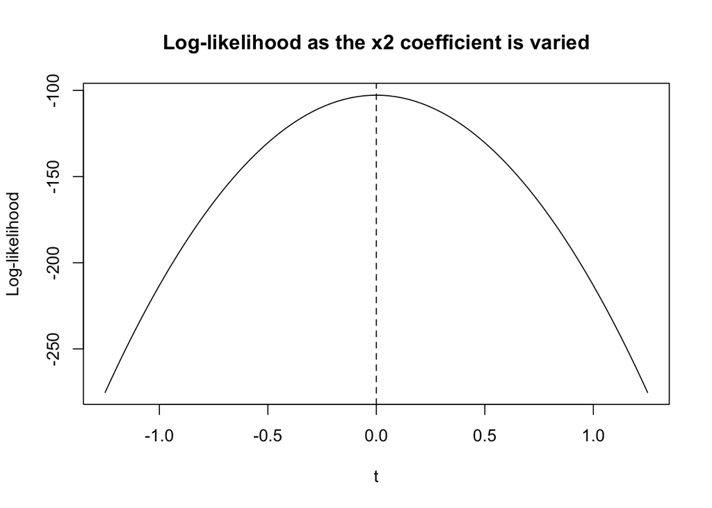

```r
plot(
  t_grid,
  loglik_values,
  type = "l",
  xlab = "t",
  ylab = "Log-likelihood",
  main = "Log-likelihood as the x2 coefficient is varied"
)

abline(v = 0, lty = 2)
```

The maximum occurs at approximately $t =$ 0, which is $0$ up to the resolution of the grid.

When $t=0$,

$$\widehat{\boldsymbol\beta}
+
t\mathbf e_{x_2}
=
\widehat{\boldsymbol\beta}.$$

Therefore, the log-likelihood is maximized at the least-squares estimate of the $x_2$ coefficient.

This agrees with part (a), where we showed that for fixed $\sigma^2$, maximizing the Gaussian log-likelihood with respect to $\boldsymbol\beta$ is equivalent to minimizing the residual sum of squares. Since $\widehat{\boldsymbol\beta}$ minimizes the residual sum of squares, moving the $x_2$ coefficient away from its least-squares estimate in either direction decreases the log-likelihood.

## Question 3 (Starting values in nonconvex optimization)

Consider the function

$$f(x)=\exp(1.5x)-3(x+6)^2-0.05x^3,$$

with derivative

$$f'(x)=1.5\exp(1.5x)-6(x+6)-0.15x^2.$$

1. Plot $f(x)$ over the interval $[-40,7]$. Based on the plot, describe the important features of the objective function that may affect numerical optimization.

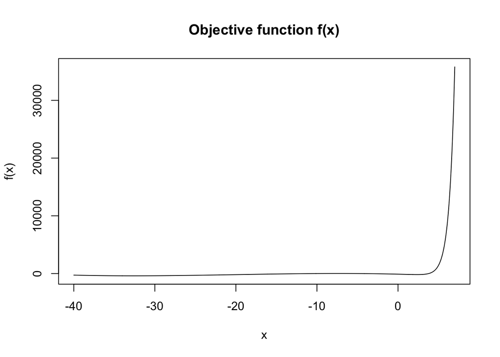

```r
# Define the objective function

f <- function(x) {

  exp(1.5 * x) - 3 * (x + 6)^2 - 0.05 * x^3

}

# Grid over the requested interval

x_grid <- seq(-40, 7, length.out = 1000)

# Evaluate the function

f_values <- f(x_grid)

# Plot

plot(

  x_grid,

  f_values,

  type = "l",

  xlab = "x",

  ylab = "f(x)",

  main = "Objective function f(x)"

)
```

The plot shows that the objective function is nonconvex and has several turning points. In particular, it contains multiple local extrema rather than a single simple peak or valley.

There is a local minimum near $x=-32.65$, a local maximum near $x=-7.35$, and another local minimum near $x=2.35$. For larger positive values of $x$, the exponential term increases very rapidly, causing the function to rise sharply.

These features can affect numerical optimization because the result may depend strongly on the starting value. An optimization method that uses only local information may converge to different stationary points depending on where it begins, rather than finding the same solution from every starting point.

2. Use BFGS to minimize $f(x)$ twice, starting at $x^{(0)}=-15$ and $x^{(0)}=0$. Supply $f'(x)$ to the optimizer. For each run, report the final value of $x$, the final objective value, $|f'(x)|$, and whether the optimizer reported convergence.

Define the derivative of the objective function:

```r
f_prime <- function(x) {
  1.5 * exp(1.5 * x) - 6 * (x + 6) - 0.15 * x^2
}
```

Run BFGS starting at $x^{(0)}=-15$:

```r
fit1 <- optim(
  par = -15,
  fn = f,
  gr = f_prime,
  method = "BFGS"
)

fit1
```

```
$par
[1] -32.64911

$value
[1] -390.3858

$counts
function gradient
      15        6

$convergence
[1] 0

$message
NULL
```

Run BFGS starting at $x^{(0)}=0$:

```r
fit2 <- optim(
  par = 0,
  fn = f,
  gr = f_prime,
  method = "BFGS"
)

fit2
```

```
$par
[1] 2.349967

$value
[1] -175.8626

$counts
function gradient
      22        6

$convergence
[1] 0

$message
NULL
```

Summarize the results:

```r
results <- data.frame(
  Starting_value = c(-15, 0),
  Final_x = c(fit1$par, fit2$par),
  Final_objective = c(fit1$value, fit2$value),
  Abs_derivative = c(
    abs(f_prime(fit1$par)),
    abs(f_prime(fit2$par))
  ),
  Convergence = c(
    fit1$convergence == 0,
    fit2$convergence == 0
  )
)

results
```

```
  Starting_value    Final_x Final_objective Abs_derivative Convergence
1            -15 -32.649111       -390.3858   8.725087e-08        TRUE
2              0   2.349967       -175.8626   6.556057e-07        TRUE
```

The run starting at $x^{(0)}=-15$ converges to approximately

$$x=-32.649,$$

with objective value approximately

$$f(x)=-390.386.$$

The run starting at $x^{(0)}=0$ converges to approximately

$$x=2.350,$$

with objective value approximately

$$f(x)=-175.863.$$

For both runs, $|f'(x)|$ is very close to zero and the optimizer reports convergence.

3. Explain why the two runs can converge to different answers. Which run gives the lower objective value? What additional evidence would be needed before claiming that this point is the global minimum?

The two BFGS runs can converge to different answers because the objective function is nonconvex and contains multiple local minima. BFGS is a local optimization method, so its result can depend on the starting value.

Starting from $x^{(0)}=-15$ leads to the minimum near

$$x=-32.649,$$

while starting from $x^{(0)}=0$ leads to the minimum near

$$x=2.350.$$

The first run gives the lower objective value because

$$-390.386 < -175.863.$$

Therefore, among these two solutions, the point near $x=-32.649$ is better for minimizing $f(x)$.

However, convergence of BFGS and a near-zero derivative only show that the optimizer has found a stationary local minimum. They do not prove that the point is the global minimum.

Before claiming a global minimum, additional evidence would be needed, such as examining the objective over the full interval, using many different starting values, locating and comparing all stationary points, or using a global optimization method.

## Question 4 (Nearly collinear predictors)

Continue with $\mathbf X$ and $\mathbf y$ from Question 1. Set the random seed to 43202 and generate

$$u_i\overset{\mathrm{iid}}{\sim}N(0,1),
\qquad i=1,\ldots,n.$$

Define

$$\mathbf x_6=\mathbf x_1+10^{-4}\mathbf u,
\qquad
\mathbf X_+
=
\begin{bmatrix}
\mathbf X & \mathbf x_6
\end{bmatrix},$$

and let

$$\mathbf y^\star=\mathbf y+10^{-3}\mathbf u.$$

Use a numerically stable least-squares routine throughout.

1. Fit $\mathbf y$ using $\mathbf X$ and $\mathbf X_+$. For each design matrix, report the condition number and training RMSE. For the augmented fit, also report the coefficients of $\mathbf x_1$ and $\mathbf x_6$.

```r
set.seed(43202)

# Generate u
u <- rnorm(n)

# x1 is column 2 because column 1 is the intercept
x1 <- X[, 2]

# Create nearly collinear predictor
x6 <- x1 + 1e-4 * u

# Augmented design matrix
X_plus <- cbind(X, x6)

# Fit y using X
beta_X <- qr.solve(X, y)
yhat_X <- as.vector(X %*% beta_X)
rmse_X <- sqrt(mean((y - yhat_X)^2))

# Fit y using X_plus
beta_Xplus <- qr.solve(X_plus, y)
yhat_Xplus <- as.vector(X_plus %*% beta_Xplus)
rmse_Xplus <- sqrt(mean((y - yhat_Xplus)^2))

# Condition numbers
kappa_X <- kappa(X)
kappa_Xplus <- kappa(X_plus)

# x1 and x6 coefficients from augmented model
coef_x1 <- beta_Xplus[2]
coef_x6 <- beta_Xplus[7]

# Report results
data.frame(
  Design = c("X", "X_plus"),
  Condition_number = c(kappa_X, kappa_Xplus),
  Training_RMSE = c(rmse_X, rmse_Xplus)
)
```

```
  Design Condition_number Training_RMSE
1      X         1.950478     0.6763696
2 X_plus     31344.795552     0.6754668
```

```r
c(
  x1_coefficient = coef_x1,
  x6_coefficient = coef_x6
)
```

```
   x1_coefficient x6_coefficient.x6
         351.6766         -350.2588
```

The condition number of $\mathbf X$ is 1.95, while the condition number of $\mathbf X_+$ is 3.134e+04. The much larger condition number for $\mathbf X_+$ indicates severe near-collinearity because $\mathbf x_6$ is almost identical to $\mathbf x_1$.

The training RMSE is 0.6764 for $\mathbf X$ and 0.6755 for $\mathbf X_+$. Thus, adding the nearly collinear predictor changes the training fit very little.

For the augmented model, the coefficient of $\mathbf x_1$ is 351.6766 and the coefficient of $\mathbf x_6$ is -350.2588.

2. Fit $\mathbf y^\star$ using $\mathbf X_+$. Report the changes in the coefficients of $\mathbf x_1$ and $\mathbf x_6$. Compare the two fitted-value vectors using their root mean squared difference and maximum absolute difference.

```r
# Create perturbed response
y_star <- y + 1e-3 * u

# Fit y_star using X_plus
beta_star <- qr.solve(X_plus, y_star)

# Fitted values
yhat_star <- as.vector(X_plus %*% beta_star)

# x1 and x6 coefficients
coef_x1_star <- beta_star[2]
coef_x6_star <- beta_star[7]

# Changes in coefficients
change_x1 <- coef_x1_star - coef_x1
change_x6 <- coef_x6_star - coef_x6

# Compare fitted-value vectors
fit_difference <- yhat_star - yhat_Xplus

rms_fit_difference <- sqrt(mean(fit_difference^2))
max_fit_difference <- max(abs(fit_difference))

# Report coefficient changes
data.frame(
  Coefficient = c("x1", "x6"),
  Original = c(coef_x1, coef_x6),
  Perturbed = c(coef_x1_star, coef_x6_star),
  Change = c(change_x1, change_x6)
)
```

```
   Coefficient  Original Perturbed Change
            x1  351.6766  341.6766    -10
x6          x6 -350.2588 -340.2588     10
```

```r
# Report fitted-value differences
c(
  RMS_difference = rms_fit_difference,
  Maximum_absolute_difference = max_fit_difference
)
```

```
             RMS_difference Maximum_absolute_difference
                0.001015879                 0.002572675
```

The coefficient of $\mathbf x_1$ changes by -10, while the coefficient of $\mathbf x_6$ changes by 10.

However, the root mean squared difference between the fitted-value vectors is only 1.016e-03, and the maximum absolute difference is 2.573e-03.

Therefore, the individual coefficients change substantially even though the fitted values change very little.

3. Use the identity

$$\mathbf y^\star-\mathbf y
=
10(\mathbf x_6-\mathbf x_1)$$

to explain why the fitted values change very little while the two coefficients change substantially. What does this example suggest about interpreting separate effects for nearly collinear predictors?

Since

$$\mathbf x_6
=
\mathbf x_1+10^{-4}\mathbf u,$$

we have

$$\mathbf x_6-\mathbf x_1
=
10^{-4}\mathbf u.$$

Multiplying by $10$ gives

$$10(\mathbf x_6-\mathbf x_1)
=
10^{-3}\mathbf u.$$

Since

$$\mathbf y^\star-\mathbf y
=
10^{-3}\mathbf u,$$

it follows that

$$\mathbf y^\star-\mathbf y
=
10(\mathbf x_6-\mathbf x_1).$$

Therefore, the small change in the response can be represented by increasing the coefficient of $\mathbf x_6$ by approximately $10$ and decreasing the coefficient of $\mathbf x_1$ by approximately $10$. Because $\mathbf x_1$ and $\mathbf x_6$ are nearly identical, these large coefficient changes nearly cancel each other in the fitted values.

This explains why the fitted values change very little even though the individual coefficients change substantially. The example shows that with nearly collinear predictors, individual coefficient estimates can be unstable and sensitive to small changes in the data. Therefore, separate effects for nearly collinear predictors should be interpreted with caution.

## Question 5 (Data preparation and summary statistics)

The file `data/data-manipulation.csv` is a small constructed data table containing an observation identifier, a group label, two numeric predictors, and a response. Some response values are missing. For analyses involving the response, use only observations with a recorded response. Do not replace a missing response with zero or a group mean.

1. Read the data and report its dimensions, column types, number of duplicated identifiers, and number of missing values in each column. Create an analysis table containing only observations with a recorded response, and define

$$\texttt{feature\_sum}=\texttt{x1}+\texttt{x2}.$$

```r
# Read the data
dat <- read.csv("data/data-manipulation.csv")

# Dimensions
dim(dat)
```

```
[1] 24  5
```

```r
# Column types
str(dat)
```

```
'data.frame':   24 obs. of  5 variables:
 $ observation_id: chr  "obs-01" "obs-02" "obs-03" "obs-04" ...
 $ group         : chr  "A" "A" "A" "A" ...
 $ x1            : num  1.2 2.4 0.8 3.1 2 1.7 2.8 1 3.5 2.7 ...
 $ x2            : num  2 1.1 2.8 1.5 2.2 1.8 0.9 2.5 1.4 2.3 ...
 $ response      : num  5.36 6.18 4.62 NA 5.52 5.64 7.18 4.7 7.84 7.24 ...
```

```r
# Number of duplicated identifiers
sum(duplicated(dat$observation_id))
```

```
[1] 0
```

```r
# Number of missing values in each column
colSums(is.na(dat))
```

```
observation_id          group             x1             x2       response
             0              0              0              0              3
```

```r
# Keep only observations with a recorded response
analysis_dat <- dat[!is.na(dat$response), ]

# Create feature_sum
analysis_dat$feature_sum <- analysis_dat$x1 + analysis_dat$x2

# View first few rows
head(analysis_dat)
```

```
  observation_id group  x1  x2 response feature_sum
1         obs-01     A 1.2 2.0     5.36         3.2
2         obs-02     A 2.4 1.1     6.18         3.5
3         obs-03     A 0.8 2.8     4.62         3.6
5         obs-05     A 2.0 2.2     5.52         4.2
6         obs-06     A 1.7 1.8     5.64         3.5
7         obs-07     A 2.8 0.9     7.18         3.7
```

The original data contain 24 observations and 5 columns. There are 0 duplicated observation identifiers.

For analyses involving the response, observations with missing response values were removed rather than replacing the missing values. The resulting analysis table contains 21 observations. The variable `feature_sum` was defined as the sum of `x1` and `x2`.

2. For each group, report the number of observations, the mean response, and the mean of `feature_sum`. State clearly which observations these summaries describe.

```r
# Group summary statistics
group_summary <- aggregate(
  cbind(response, feature_sum) ~ group,
  data = analysis_dat,
  FUN = function(x) c(n = length(x), mean = mean(x))
)

# Create a cleaner summary table
group_results <- data.frame(
  group = group_summary$group,
  n = group_summary$response[, "n"],
  mean_response = group_summary$response[, "mean"],
  mean_feature_sum = group_summary$feature_sum[, "mean"]
)

group_results
```

```
  group n mean_response mean_feature_sum
1     A 7      5.600000         3.600000
2     B 7      7.602857         4.928571
3     C 7      7.997143         6.585714
```

These summaries describe only the observations with a recorded, nonmissing response. Observations with a missing response in the original data are not included.

For each group, the table reports the number of retained observations, the mean response, and the mean of `feature_sum`.

3. Sort the analysis table by response from largest to smallest and report the first three rows, including `observation_id`, `group`, `response`, and `feature_sum`. Add code checks verifying that the number of retained rows equals the number of nonmissing responses in the original data, that the analysis table has no missing response values, and that its identifiers are unique.

```r
# Sort by response from largest to smallest
sorted_dat <- analysis_dat[
  order(analysis_dat$response, decreasing = TRUE),
]

# Report requested columns for the first three rows
top_three <- sorted_dat[
  1:3,
  c("observation_id", "group", "response", "feature_sum")
]

top_three
```

```
   observation_id group response feature_sum
22         obs-22     C     9.24         6.6
16         obs-16     B     9.00         5.2
14         obs-14     B     8.66         5.0
```

The three rows above have the largest response values among observations with a recorded response.

The following checks verify the construction of the analysis table:

```r
# Check 1:
# Retained rows equal number of nonmissing responses
nrow(analysis_dat) == sum(!is.na(dat$response))
```

```
[1] TRUE
```

```r
# Check 2:
# No missing responses remain
sum(is.na(analysis_dat$response)) == 0
```

```
[1] TRUE
```

```r
# Check 3:
# Identifiers in analysis table are unique
anyDuplicated(analysis_dat$observation_id) == 0
```

```
[1] TRUE
```

All three checks should return `TRUE`. This confirms that the analysis table contains exactly the observations with nonmissing responses, contains no missing response values, and has unique observation identifiers.

## Question 6 (Can 39 million Fitbit records represent US adults?)

[Patten et al. (2026)](https://doi.org/10.1038/s41591-026-04352-3) describe Fitbit data from 59,018 participants in the All of Us Research Program. The dataset spans 14 years and contains more than 39 million daily step records. Participants contributed data through one of two routes:

- Bring Your Own Device (BYOD): participants shared data from a Fitbit they already owned.
- Wearables Enhancing All of Us Research (WEAR): invited participants received a Fitbit at no cost.

In the general activity cohort, the BYOD and WEAR groups contained 32,035 and 22,474 participants, respectively. The BYOD value is listed first in each comparison below:

- 77.3% versus 55.1% reported being White;
- 6.1% versus 15.2% reported annual household income between $\$10{,}000$ and $\$25{,}000$; and
- median daily steps were 6,867 versus 5,797.

Suppose the target is the mean of the participant-specific average daily step counts among US adults during the study period, with each adult given equal weight. A researcher writes:

> “This dataset contains more than 39 million daily Fitbit records. Therefore, the average of all recorded step counts should provide an accurate estimate of mean daily activity among US adults.”
1. Are the 39 million daily records independent observations? What characteristics or behaviors could cause some participants to contribute more recorded days than others? Explain how averaging all recorded days would then weight participants unequally.

The 39 million daily records are not independent observations. Many daily records come from the same participant, so observations from the same person are likely to be correlated. For example, a person’s activity level on one day may be similar to their activity level on nearby days.

Participants may also contribute different numbers of recorded days. Differences could result from how long a participant was enrolled, how consistently they wore or synchronized their Fitbit, device loss or malfunction, or decisions to stop sharing data.

Therefore, averaging all recorded daily step counts would give more weight to participants who contributed more days. A participant with 1,000 recorded days would influence the average much more than a participant with 100 recorded days. This does not match the stated target, which gives each US adult equal weight.

2. BYOD participants reported a median of 6,867 daily steps, compared with 5,797 among WEAR participants. Does this comparison show that already owning a Fitbit causes people to walk more? Explain your answer and give at least one plausible alternative explanation based on how participants entered the two groups.

No. The higher median daily step count among BYOD participants does not show that already owning a Fitbit causes people to walk more. The participants were not randomly assigned to already own a Fitbit or to receive one through WEAR, so the two groups may differ in other ways that are related to physical activity.

For example, people who already owned a Fitbit may have been more interested in fitness or more physically active before entering the study. The reported demographic differences between BYOD and WEAR participants also show that the groups were not identical in their composition.

Therefore, the difference of 6,867 versus 5,797 median daily steps is an observational association. It could be explained by pre-existing differences between the people entering the two groups rather than a causal effect of Fitbit ownership.

3. A very large dataset can still produce a biased estimate of a population quantity when the people and observations entering the dataset are selected. Using this study, explain how selection of both participants and recorded days could make the observed data differ from the US adult population. Why might the naive average of all recorded daily step counts fail to estimate the stated target? You do not need to determine the direction of the bias.

The large number of records does not guarantee that the dataset is representative of US adults. Participant selection can create bias because people who participate in the All of Us Research Program and provide Fitbit data may differ systematically from US adults who do not participate. The differences between the BYOD and WEAR groups in race, income, and activity also demonstrate that the way participants enter the dataset is related to participant characteristics.

There can also be selection at the level of recorded days. Participants contribute different numbers of days, and whether a day is recorded may depend on behaviors such as wearing, charging, or synchronizing the Fitbit. If the probability that a day is recorded is related to a person’s activity, the observed days may not represent all days equally.

The naive average of all daily records therefore has two problems relative to the stated target. First, the participants with Fitbit data may not represent the US adult population. Second, averaging all records gives greater weight to participants who contribute more recorded days, while the target gives each adult equal weight.

Thus, even with more than 39 million records, the naive average can be a very precise estimate of the wrong quantity. Increasing the number of selected observations reduces sampling variability but does not necessarily remove bias caused by participant selection or unequal observation of days.

### Source

Patten, T., Preble, E. A., Master, H., et al. (2026). [The All of Us Research Program’s wearables dataset](https://doi.org/10.1038/s41591-026-04352-3). *Nature Medicine*, 32, 2302-2310.